# CP06_2 - BMW vs. Volkswagen

Diego Senso González

13/12/2020

# Objetivo

El objetivo del presente informe es estudiar si existe cointegracíon entre las series temporales de BMW y Volkswagen.

# ¿Están cointegradas?

Extraemos los datos de cotización de ambas empresas desde el 1 de enero de 2014 hasta el 12 de diciembre de 2020. Visualizamos las dos series por separado y realizamos el Dickey-Fuller Test para cada una:

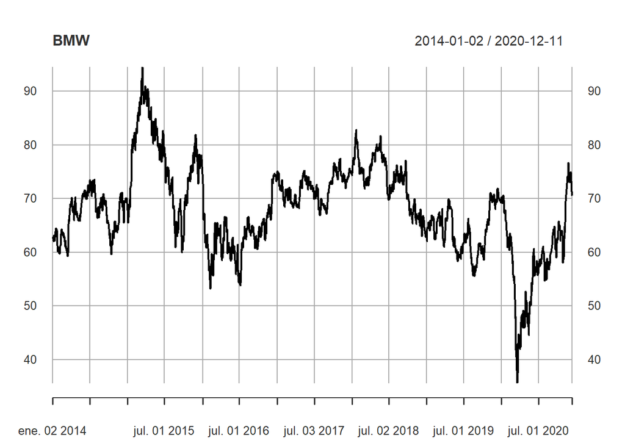

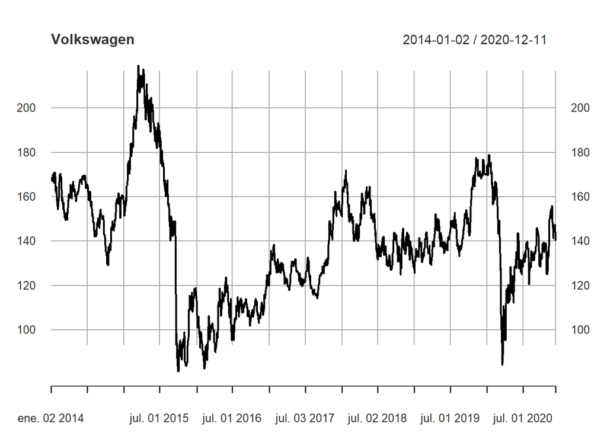

```
##
##  Augmented Dickey-Fuller Test
##
## data:  bmwdata
## Dickey-Fuller = -3.1217, Lag order = 0, p-value = 0.1035
## alternative hypothesis: stationary
```

```
##
##  Augmented Dickey-Fuller Test
##
## data:  voldata
## Dickey-Fuller = -2.4339, Lag order = 0, p-value = 0.3946
## alternative hypothesis: stationary
```

```
##
##  Augmented Dickey-Fuller Test
##
## data:  bmwdata
## Dickey-Fuller = -3.3081, Lag order = 6, p-value = 0.06928
## alternative hypothesis: stationary
```

```
##
##  Augmented Dickey-Fuller Test
##
## data:  voldata
## Dickey-Fuller = -2.634, Lag order = 6, p-value = 0.3099
## alternative hypothesis: stationary
```

Probando el test con diferentes valores de “k” (lag order o número de retardos), la interpretación es que se acepta la hipótesis nula, por lo que las series no son estacionarias. Completamos el análisis con el “Augmented Dickey-Fuller Test”:

```
##
## ###############################################
## # Augmented Dickey-Fuller Test Unit Root Test #
## ###############################################
##
## Test regression none
##
##
## Call:
## lm(formula = z.diff ~ z.lag.1 - 1 + z.diff.lag)
##
## Residuals:
##     Min      1Q  Median      3Q     Max
## -5.9704 -0.5881 -0.0054  0.5816  5.4759
##
## Coefficients:
##               Estimate Std. Error t value Pr(>|t|)
## z.lag.1     -9.142e-05  3.862e-04  -0.237   0.8129
## z.diff.lag1  5.277e-02  2.392e-02   2.206   0.0275 *
## z.diff.lag2  2.101e-02  2.394e-02   0.878   0.3803
## z.diff.lag3  4.882e-02  2.394e-02   2.039   0.0416 *
## z.diff.lag4 -4.722e-02  2.394e-02  -1.973   0.0487 *
## ---
## Signif. codes:  0 '***' 0.001 '**' 0.01 '*' 0.05 '.' 0.1 ' ' 1
##
## Residual standard error: 1.105 on 1744 degrees of freedom
## Multiple R-squared:  0.007674,   Adjusted R-squared:  0.004829
## F-statistic: 2.697 on 5 and 1744 DF,  p-value: 0.01954
##
##
## Value of test-statistic is: -0.2367
##
## Critical values for test statistics:
##       1pct  5pct 10pct
## tau1 -2.58 -1.95 -1.62
```

```
##
## ###############################################
## # Augmented Dickey-Fuller Test Unit Root Test #
## ###############################################
##
## Test regression none
##
##
## Call:
## lm(formula = z.diff ~ z.lag.1 - 1 + z.diff.lag)
##
## Residuals:
##      Min       1Q   Median       3Q      Max
## -25.6943  -1.4349  -0.0072   1.5039  15.6379
##
## Coefficients:
##               Estimate Std. Error t value Pr(>|t|)
## z.lag.1     -0.0003386  0.0004777  -0.709  0.47856
## z.diff.lag1  0.1164001  0.0239533   4.859 1.28e-06 ***
## z.diff.lag2 -0.0270636  0.0240537  -1.125  0.26069
## z.diff.lag3  0.0481414  0.0240418   2.002  0.04540 *
## z.diff.lag4 -0.0328294  0.0240691  -1.364  0.17276
## z.diff.lag5  0.0019161  0.0240663   0.080  0.93655
## z.diff.lag6 -0.0343690  0.0240383  -1.430  0.15297
## z.diff.lag7  0.0659078  0.0240444   2.741  0.00619 **
## z.diff.lag8 -0.0487724  0.0239388  -2.037  0.04176 *
## ---
## Signif. codes:  0 '***' 0.001 '**' 0.01 '*' 0.05 '.' 0.1 ' ' 1
##
## Residual standard error: 2.835 on 1740 degrees of freedom
## Multiple R-squared:  0.02153,    Adjusted R-squared:  0.01646
## F-statistic: 4.253 on 9 and 1740 DF,  p-value: 1.787e-05
##
##
## Value of test-statistic is: -0.7088
##
## Critical values for test statistics:
##       1pct  5pct 10pct
## tau1 -2.58 -1.95 -1.62
```

```
## Response: bmwData
## Input: volData
## Number of inputs: 1
## Model: y ~ X + 1
## -------------------------------
## Engle-Granger Cointegration Test
## alternative: cointegrated
##
## Type 1: no trend
##     lag      EG p.value
##  7.0000 -2.8194  0.0574
## -----
##  Type 2: linear trend
##     lag      EG p.value
##   7.000  -0.333   0.100
## -----
##  Type 3: quadratic trend
##     lag      EG p.value
##    7.00    1.52    0.10
## -----------
## Note: p.value = 0.01 means p.value <= 0.01
##     : p.value = 0.10 means p.value >= 0.10
```

A la vista de los resultados, cabe concluir que las series no están cointegradas. En todos los casos se acepta la hipótesis nula.

## Conclusiones

Cabe concluir que las series de BMW y Volkswagen no están cointegradas.